# Donor Profile: Private donors

## Transaction Volatility

Private donor funding demonstrates substantial volatility, presenting a critical strategic lever for enhancing emergency response financing. Analysis reveals an average transaction amount of $242.6K across 2,195 transactions annually, markedly lower than top donors’ $3.3M average through only 268 transactions. This discrepancy highlights a fragmentation in private donor contributions that limits impact scalability and risks funding gaps during critical periods. Addressing this, investment in donor consolidation and transaction optimization could multiply impact by reducing transaction overhead while increasing average gift size. Prioritizing these adjustments supports UNHCR’s strategic aim to stabilize funding streams, ensure predictable resource flow, and enable rapid scaling in crises. Immediate executive action to engage major donors with evidence-based proposals targeting transaction efficiency and aggregate funding growth presents a high-ROI opportunity for sustainable donor partnerships. Leveraging precise transaction timing and value insights enhances accountability and donor confidence, strengthening innovation in private fundraising. Decision-makers must seize this window to recalibrate partnership strategies, mitigating volatility risks and unlocking a reliable private donor base as a key pillar for future operations.

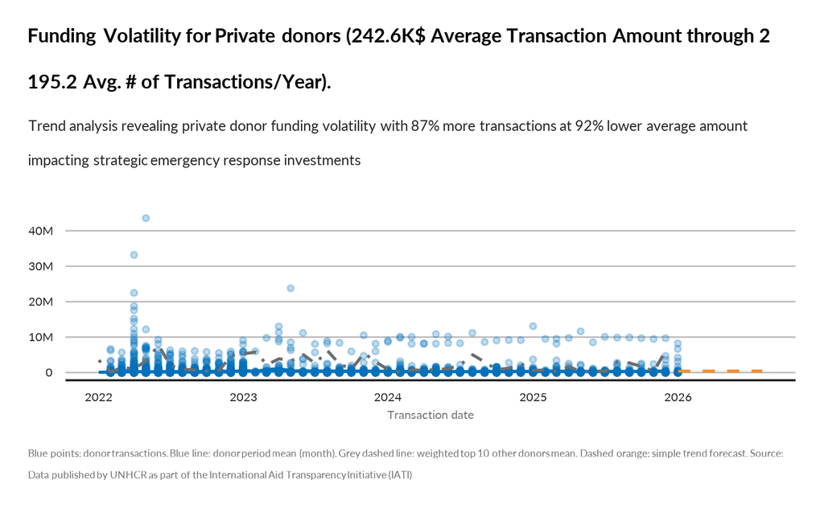

TRUE